```python
%matplotlib inline
import matplotlib
import matplotlib.pyplot as plt
import scipy
from scipy import stats
from scipy.optimize import curve_fit as cv
import numpy as np
# import library
import pickle
```

```python
def histograms(var, name, units):
    plt.rcParams["figure.figsize"] = (40,50)
    fig, ax = plt.subplots(2, 2)
    # Higgs data | log Higgs
    # ----------------------
    # QCD data  | log QCD
    higgs_hist = ax[0, 0]
    higgs_log = ax[0, 1]
    qcd_hist = ax[1, 0]
    qcd_log = ax[1, 1]


    a = higgs_hist.hist(higgs_data.get(var), density = True, bins = 50, alpha = 0.6)
    higgs_hist.set_title(name + ' for Higgs data set')
    higgs_hist.set_xlabel(name + units)
    higgs_hist.set_ylabel('frequency')

    b = higgs_log.hist(higgs_data.get(var), density = True, bins = 50, alpha = 0.8)
    higgs_log.set_title('Log of ' + name + ' for Higgs data set')
    higgs_log.set_yscale('log')
    higgs_log.set_xlabel(name + units)
    higgs_log.set_ylabel('log(frequency)')

    c = qcd_hist.hist(qcd_data.get(var), density = True, bins = 50, color = 'r', alpha = 0.6)
    qcd_hist.set_title(name + ' for QCD data set')
    qcd_hist.set_xlabel(name + units)
    qcd_hist.set_ylabel('frequency')

    d = qcd_log.hist(qcd_data.get(var), density = True, bins = 50, color = 'r', alpha = 0.8)
    qcd_log.set_title('Log of ' + name + ' for QCD data set')
    qcd_log.set_yscale('log')
    qcd_log.set_xlabel(name + units)
    qcd_log.set_ylabel('log(frequency)')

    for plot in [higgs_hist, higgs_log, qcd_hist, qcd_log]:
        plot.title.set_fontsize(48)
        for item in ([plot.xaxis.label, plot.yaxis.label] + plot.get_xticklabels() + plot.get_yticklabels()):
            item.set_fontsize(36)
```

# Lab 5

This lab is focused on exploring the background for the "real world" data that we will see over the coming labs. My partner and I selected the LHC data for these labs. He will be working on the 1000 to 1200 data and I will be using the 250 to 500 data set.

The Large Hadron Collider (LHC) is a multinational particle accelerator in France and Switzerland. It is the largest and highest energy particle accelerator in the world. A hadron is a subatomic particle made of multiple quarks bound by the strong nuclear force. While there are several detectors at the LHC, of interest for these labs is ATLAS (A Toroidal LHC Apparatus), which was conceived in 1992 and became operational in 2008. One of the main goals for ATLAS was to either confirm or deny the existance of the Higgs boson, a missing piece in the standard model theory of particle physics which was first theorized to exist in 1964 and was proposed to give the W and Z gauge bosons mass, particles which had previously been predicted to be massless. The tricky part in detecting the Higgs boson is related to its mass. It is an incredibly massive relative to other subatomic particles and has a very short halflife.

The data set I will be using is derived from proton-proton collisions at an energy of $\sqrt{s} = 13$ TeV. Higgs bosons from this collision should decay into a bottom quark-antiquark pair, two bosons, and two photons. It's not quite that simple, though, since there can be a whole host of produced particles and decays in the collision as well. To model this, we are given two sets of data, one that represents the Higgs data and one from quantum chromodynamic (QCD) contamination from strong interactions between quarks and gluons.

We will start by defining our variables, all of the units are inferred

```python
# open the file of interest, and use pickle loading
infile = open ("Sample_pt_250_500/qcd_100000_pt_250_500.pkl",'rb')
qcd_data = pickle.load(infile)
higgs_data = pickle.load(open ("Sample_pt_250_500/higgs_100000_pt_250_500.pkl",'rb'))

# list all keys of the files
print(qcd_data.keys())
higgs_data.keys()
```

```
Index(['pt', 'eta', 'phi', 'mass', 'ee2', 'ee3', 'd2', 'angularity', 't1',
       't2', 't3', 't21', 't32', 'KtDeltaR'],
      dtype='object')
```

```
Index(['pt', 'eta', 'phi', 'mass', 'ee2', 'ee3', 'd2', 'angularity', 't1',
       't2', 't3', 't21', 't32', 'KtDeltaR'],
      dtype='object')
```

| Variable | Symbol | Meaning | Equation | Comment |
| --- | --- | --- | --- | --- |
| pt | $p_t$ | transverse momentum | $$ \sqrt{p_x^2 + p_y^2}$$ | transverse refers to in the x, y plane, which is perpendicular to the beam line of the particles |
| eta | $\eta$ | psuedorapidity | $$ - \ln( \tan(\frac{\theta}{2}))$$ | Angle of the particle relative to the beam axis |
| phi | $\phi$ | azimuthal angle | $$\cos^{-1}\frac{x}{r} $$ | Angle above the x axis |
| mass | m | invariant (rest) mass | $$ E^2=p^2+m^2 $$ |  |
| ee2 | $e_2$ | 2-point ECF ratio | $$ \sum_{i < j \in J} p_{T,i} p_{T,j} \Delta R_{ij} \frac{1}{p_{T,J}^2}$$ | ECF = Energy correlation function |
| ee3 | $e_3$ | 3-point ECF ratio | $$\sum_{i < j < k \in J} p_{T,i} p_{T,j} p_{T,k} \Delta R_{ij} \Delta R_{jk} \Delta R_{jk} \frac{1}{p_{T,J}^3}$$ |  |
| d2 | $D_2$ | 3-to-2-point ECF ratio | $$\frac{e_3}{e_2^3}$$ |  |
| angularity | $\tau_2$ |  | $$\frac{1}{m_J} \sum_{i \in J} E_i \sin^{-2}(\theta_i) \cos^3 ( \theta_i )$$ |  |

To start, I will make histograms of the key variables. To start with, the transvere momentum histograms:

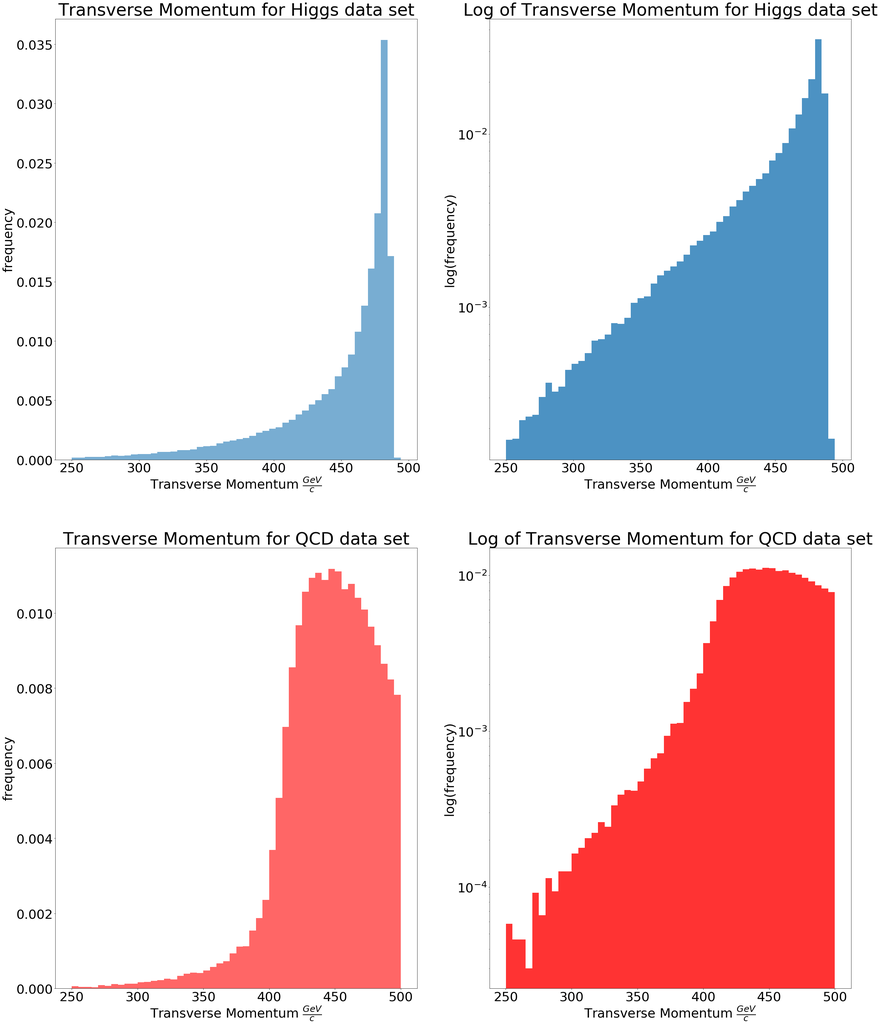

```python
histograms('pt', 'Transverse Momentum', r' $\frac{GeV}{c}$')
```

The next interesting variable to analyze is the rest mass:

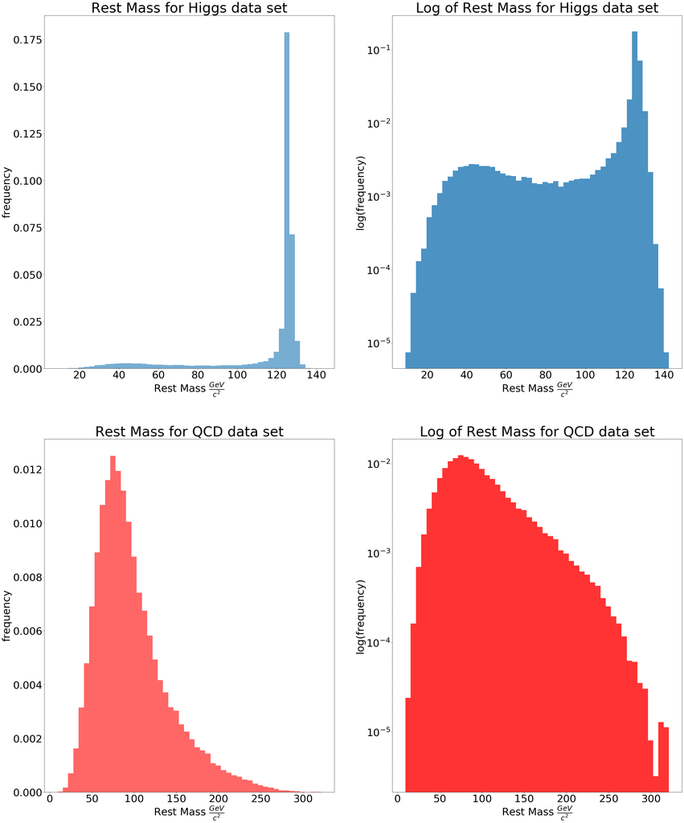

```python
histograms('mass', 'Rest Mass', r' $\frac{GeV}{c^2}$')
```

The rest mass for the Higgs peaks at about 125 $\frac{GeV}{c^2}$ and has a much less pronounced peak at around 35 $\frac{GeV}{c^2}$ with an otherwise pretty even distribution with the largest rest masses being at 140 $\frac{GeV}{c^2}$. The background QCD distribution peaks at around 75 $\frac{GeV}{c^2}$ and could be a Poisson distribution or a Rayleigh distribution. To check these, I will create the corrosponding Poisson and Rayleigh distributions and calculate the $R^2$ value for each. $R^2$ is a fitness measurement defined as $1 - \frac{SSR}{SST}$ where SSR is the squared sum of the residuals (the actual minus expected value at that point, squared) and SST is the squared sum of total (the average value of the distribution minus the value at each point, squared).

```python
def r_squared(y_expected, y_actual):
    y_bar = sum(y_actual) / y_actual.size
    ss_tot = sum((y_actual - y_bar)**2)
    ss_res = sum((y_actual - y_expected)**2)
    return 1 - (ss_res / ss_tot)
```

```
R-Squared Poisson:  -0.05490224655600895
R-Squared Rayleigh:  0.9120265572676962
```

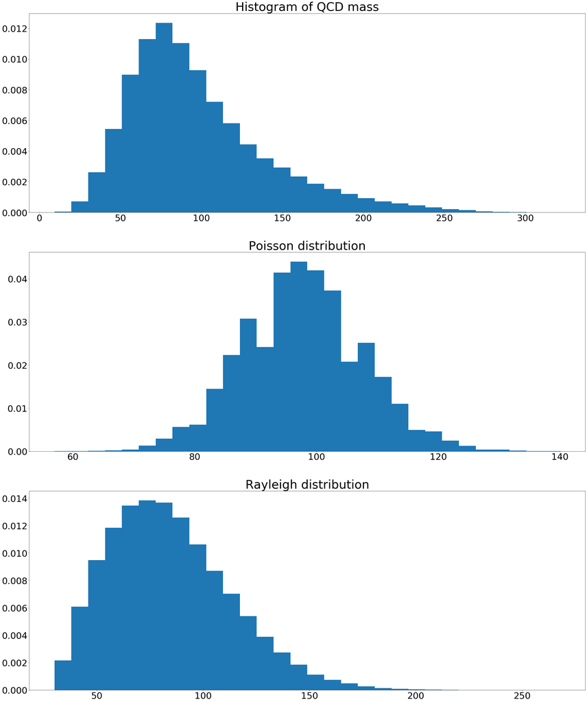

```python
mu = np.mean(qcd_data.get('mass'))
poisson = stats.poisson.rvs(mu, size=qcd_data.get('mass').size)

sigma = np.std(qcd_data.get('mass'))
rayleigh = stats.rayleigh.rvs(loc=30, scale=sigma, size = qcd_data.get('mass').size)

fig, ax = plt.subplots(3, 1)
ax[0].set_title('Histogram of QCD mass')
histActual = ax[0].hist(qcd_data.get('mass'), density = True, bins = 30)
ax[1].set_title('Poisson distribution')
histPoisson = ax[1].hist(poisson, density=True, bins = 30)
ax[2].set_title('Rayleigh distribution')
histRayleigh = ax[2].hist(rayleigh, density = True, bins = 30)

for plot in [ax[0], ax[1], ax[2]]:
    plot.title.set_fontsize(48)
    for item in ([plot.xaxis.label, plot.yaxis.label] + plot.get_xticklabels() + plot.get_yticklabels()):
        item.set_fontsize(36)

print('R-Squared Poisson: ', r_squared(histPoisson[1], histActual[1]))
print('R-Squared Rayleigh: ', r_squared(histRayleigh[1], histActual[1]))
```

As we can see from the graphs and the $R^2$ values, a Poisson distribution does a horrific job at modeling this background and a Rayleigh distribution does a pretty good job.

Regardless of the exact distribution, the background does have a significant presence in the region of the distribution where the peak of the Higgs distribution lies, which will add difficulty in filtering out the background.

The last variable which shows a significant difference between the two distributions is the 2-point ECF ratio:

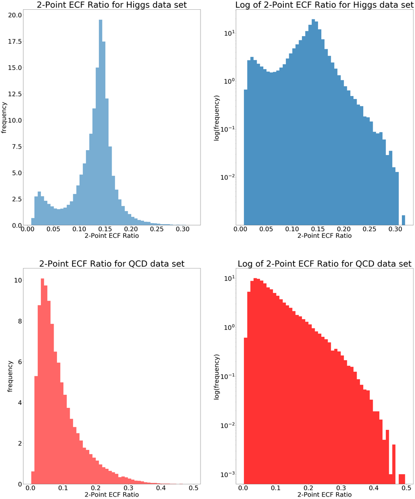

```python
histograms('ee2','2-Point ECF Ratio','')
```

The energy correlation function is, put as simply as possible, a measurement of how much of the energy of a collection of particles is in the same general direction. It is a relatively new concept, with the earliest comprehensive paper on it that I could find being published in late 2013, which credits articles from 2005 and 2011 as independently defining the 2-Point variety.

```
R-Squared Expon:  -212382.40797878444
R-Squared Rayleigh:  0.516914302148116
```

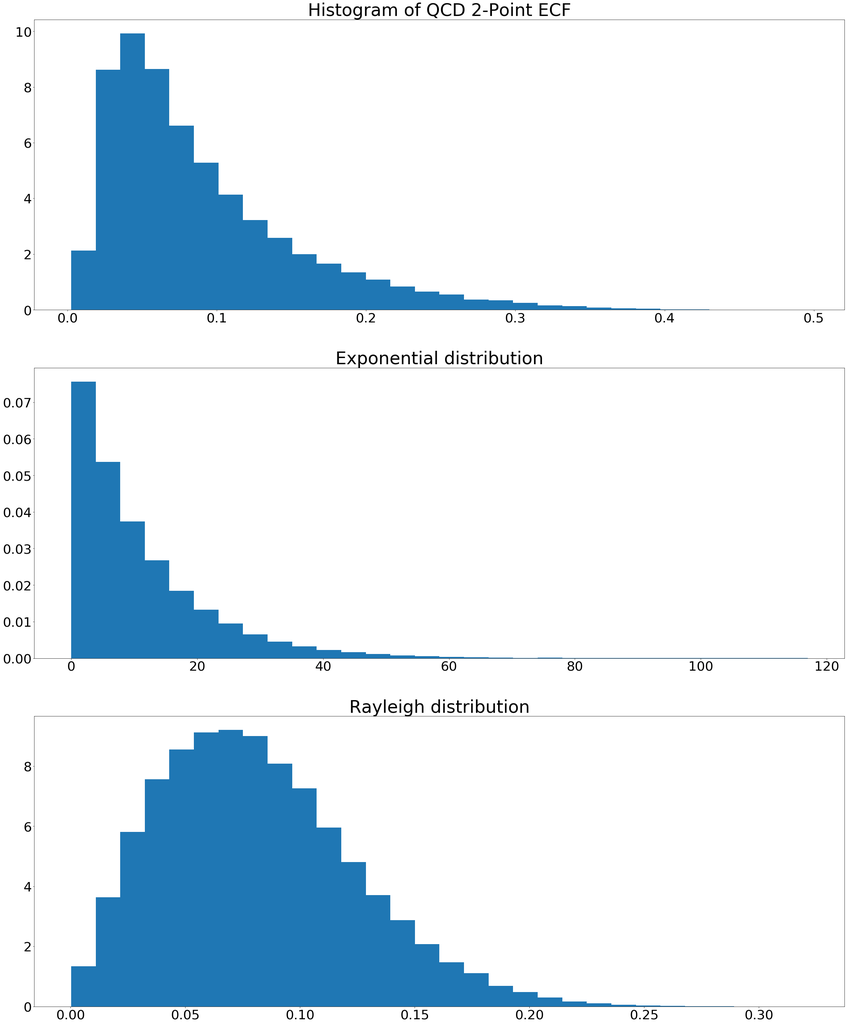

```python
mu = np.mean(qcd_data.get('ee2'))
lam = 1 / mu
expon = stats.expon.rvs(scale=lam, size=qcd_data.get('mass').size)

sigma = np.std(qcd_data.get('ee2'))
rayleigh = stats.rayleigh.rvs(loc=0, scale=sigma, size = qcd_data.get('mass').size)

fig, ax = plt.subplots(3, 1)
ax[0].set_title('Histogram of QCD 2-Point ECF')
histActual = ax[0].hist(qcd_data.get('ee2'), density = True, bins = 30)
ax[1].set_title('Exponential distribution')
histExpon = ax[1].hist(expon, density=True, bins = 30)
ax[2].set_title('Rayleigh distribution')
histRayleigh = ax[2].hist(rayleigh, density = True, bins = 30)

for plot in [ax[0], ax[1], ax[2]]:
    plot.title.set_fontsize(48)
    for item in ([plot.xaxis.label, plot.yaxis.label] + plot.get_xticklabels() + plot.get_yticklabels()):
        item.set_fontsize(36)

print('R-Squared Expon: ', r_squared(histExpon[1], histActual[1]))
print('R-Squared Rayleigh: ', r_squared(histRayleigh[1], histActual[1]))
```

Turns out these both are pretty bad at modeling, the background, but the Rayleigh does a better job.